# Supper_store_IP

Stephen Njuguna

2/4/2022

# Supper Market, Marketing Strategy

## Defining the question

Coming up with the best marketing strategy

## Defining the metric for success

Being able to inform the marketing the department of the best marketing the strategy that will result to the highest number of sales.

## Understanding the context

Marketing strategy provides an organization an edge over it’s competitors. Strategy helps in developing goods and services with best profit making potential. It also helps an organization to make optimum utilization of its resources so as to provide a sales message to it’s target market and increase its profit margins.

## Experimental design

- Data Cleaning and Preparation
- Deal with missing values
- Deal with duplicated records
- Univariate Analysis
- Bivariate Analysis
- Multivariate Analysis
- Dimension Reduction
- Feature Selection
- Association Analysis
- Anomaly Reduction
- Conclusion
- Recommendations

## Reading data

```r
#Loading dataset
supper_df <- read.csv('http://bit.ly/CarreFourDataset')
head(supper_df)
```

```
##    Invoice.ID Branch Customer.type Gender           Product.line Unit.price
## 1 750-67-8428      A        Member Female      Health and beauty      74.69
## 2 226-31-3081      C        Normal Female Electronic accessories      15.28
## 3 631-41-3108      A        Normal   Male     Home and lifestyle      46.33
## 4 123-19-1176      A        Member   Male      Health and beauty      58.22
## 5 373-73-7910      A        Normal   Male      Sports and travel      86.31
## 6 699-14-3026      C        Normal   Male Electronic accessories      85.39
##   Quantity     Tax      Date  Time     Payment   cogs gross.margin.percentage
## 1        7 26.1415  1/5/2019 13:08     Ewallet 522.83                4.761905
## 2        5  3.8200  3/8/2019 10:29        Cash  76.40                4.761905
## 3        7 16.2155  3/3/2019 13:23 Credit card 324.31                4.761905
## 4        8 23.2880 1/27/2019 20:33     Ewallet 465.76                4.761905
## 5        7 30.2085  2/8/2019 10:37     Ewallet 604.17                4.761905
## 6        7 29.8865 3/25/2019 18:30     Ewallet 597.73                4.761905
##   gross.income Rating    Total
## 1      26.1415    9.1 548.9715
## 2       3.8200    9.6  80.2200
## 3      16.2155    7.4 340.5255
## 4      23.2880    8.4 489.0480
## 5      30.2085    5.3 634.3785
## 6      29.8865    4.1 627.6165
```

```r
#Preview the data types

str(supper_df)
```

```
## 'data.frame':    1000 obs. of  16 variables:
##  $ Invoice.ID             : chr  "750-67-8428" "226-31-3081" "631-41-3108" "123-19-1176" ...
##  $ Branch                 : chr  "A" "C" "A" "A" ...
##  $ Customer.type          : chr  "Member" "Normal" "Normal" "Member" ...
##  $ Gender                 : chr  "Female" "Female" "Male" "Male" ...
##  $ Product.line           : chr  "Health and beauty" "Electronic accessories" "Home and lifestyle" "Health and beauty" ...
##  $ Unit.price             : num  74.7 15.3 46.3 58.2 86.3 ...
##  $ Quantity               : int  7 5 7 8 7 7 6 10 2 3 ...
##  $ Tax                    : num  26.14 3.82 16.22 23.29 30.21 ...
##  $ Date                   : chr  "1/5/2019" "3/8/2019" "3/3/2019" "1/27/2019" ...
##  $ Time                   : chr  "13:08" "10:29" "13:23" "20:33" ...
##  $ Payment                : chr  "Ewallet" "Cash" "Credit card" "Ewallet" ...
##  $ cogs                   : num  522.8 76.4 324.3 465.8 604.2 ...
##  $ gross.margin.percentage: num  4.76 4.76 4.76 4.76 4.76 ...
##  $ gross.income           : num  26.14 3.82 16.22 23.29 30.21 ...
##  $ Rating                 : num  9.1 9.6 7.4 8.4 5.3 4.1 5.8 8 7.2 5.9 ...
##  $ Total                  : num  549 80.2 340.5 489 634.4 ...
```

```r
#Preview dataset dimension
dim(supper_df)
```

```
## [1] 1000   16
```

## Data Cleaning

```r
#Checking for missing values
colSums(is.na(supper_df))
```

```
##              Invoice.ID                  Branch           Customer.type
##                       0                       0                       0
##                  Gender            Product.line              Unit.price
##                       0                       0                       0
##                Quantity                     Tax                    Date
##                       0                       0                       0
##                    Time                 Payment                    cogs
##                       0                       0                       0
## gross.margin.percentage            gross.income                  Rating
##                       0                       0                       0
##                   Total
##                       0
```

```r
#Checking for duplicates and dealing with them
supper_df <- unique(supper_df)
```

## Exploratory Data Analysis

### Univeriate Analysis

```r
#Previewing statistical analysis of the dataset
numeric_supper_df <- supper_df[c('Unit.price','Quantity','Tax','cogs','gross.margin.percentage','gross.income','Rating','Total')]

summary(numeric_supper_df)
```

```
##    Unit.price       Quantity          Tax               cogs
##  Min.   :10.08   Min.   : 1.00   Min.   : 0.5085   Min.   : 10.17
##  1st Qu.:32.88   1st Qu.: 3.00   1st Qu.: 5.9249   1st Qu.:118.50
##  Median :55.23   Median : 5.00   Median :12.0880   Median :241.76
##  Mean   :55.67   Mean   : 5.51   Mean   :15.3794   Mean   :307.59
##  3rd Qu.:77.94   3rd Qu.: 8.00   3rd Qu.:22.4453   3rd Qu.:448.90
##  Max.   :99.96   Max.   :10.00   Max.   :49.6500   Max.   :993.00
##  gross.margin.percentage  gross.income         Rating           Total
##  Min.   :4.762           Min.   : 0.5085   Min.   : 4.000   Min.   :  10.68
##  1st Qu.:4.762           1st Qu.: 5.9249   1st Qu.: 5.500   1st Qu.: 124.42
##  Median :4.762           Median :12.0880   Median : 7.000   Median : 253.85
##  Mean   :4.762           Mean   :15.3794   Mean   : 6.973   Mean   : 322.97
##  3rd Qu.:4.762           3rd Qu.:22.4453   3rd Qu.: 8.500   3rd Qu.: 471.35
##  Max.   :4.762           Max.   :49.6500   Max.   :10.000   Max.   :1042.65
```

```r
#Plot customer type
table(supper_df$Payment)
```

```
##
##        Cash Credit card     Ewallet
##         344         311         345
```

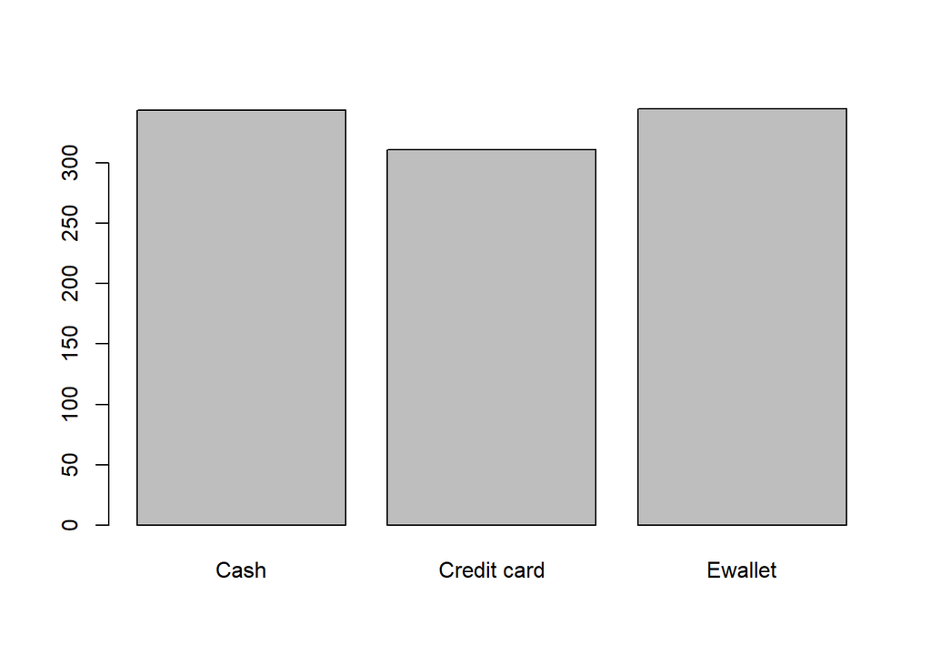

```r
barplot(table(supper_df$Payment))
```

Most customers are paying with cash and Ewallet

```r
#Plot products that most customers by
table(supper_df$Product.line)
```

```
##
## Electronic accessories    Fashion accessories     Food and beverages
##                    170                    178                    174
##      Health and beauty     Home and lifestyle      Sports and travel
##                    152                    160                    166
```

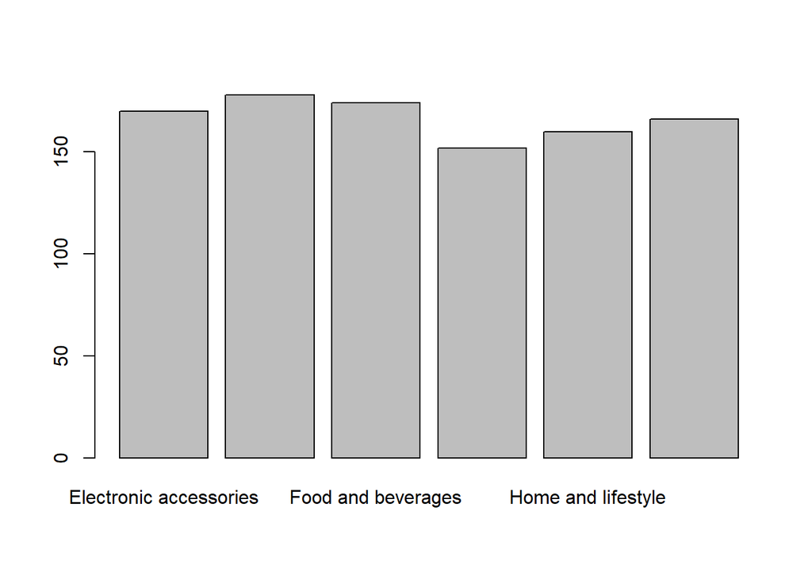

```r
barplot(table(supper_df$Product.line))
```

Fashion accessories are the most bought products followed closely by food and beverages, the least bought products are health and beauty.